# Presentation R

2/22/2018

## R Markdown

This presentation aims at showing the features of **R**. The roadmap of the session is:

- Why R
- What Can We Do with R

## R community

- R is an open source: A big community in StackOverflow

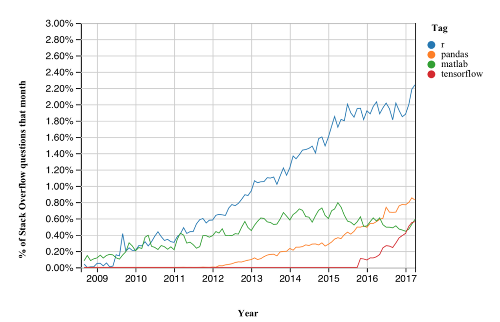

## R for Academic

- R is very popular amoung academic

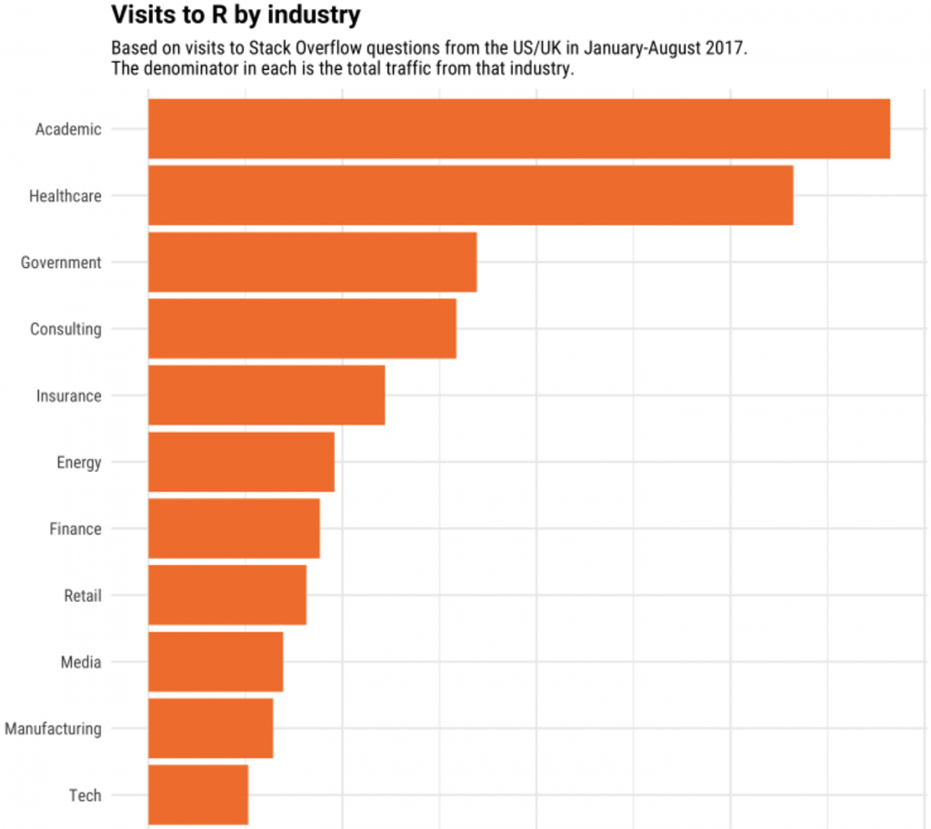

## R for Business

- R is in heavy use at several of the best companies who are hiring data scientists.
  - Google
  - Facebook
  - Twitter
  - Uber
  - Microsoft
  - World Bank

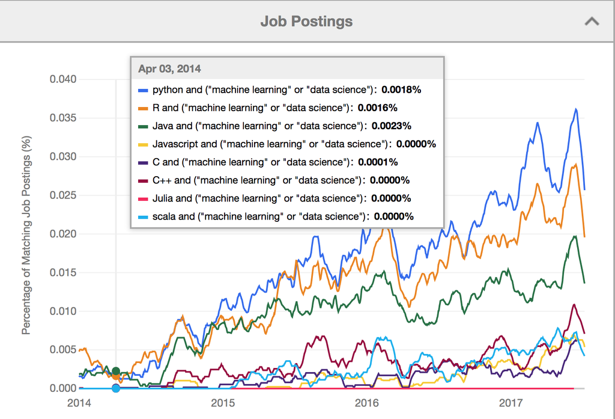

## R for Business and academic

- As data science matures, data scientists in the business world will need to communicate more with academic scientists.

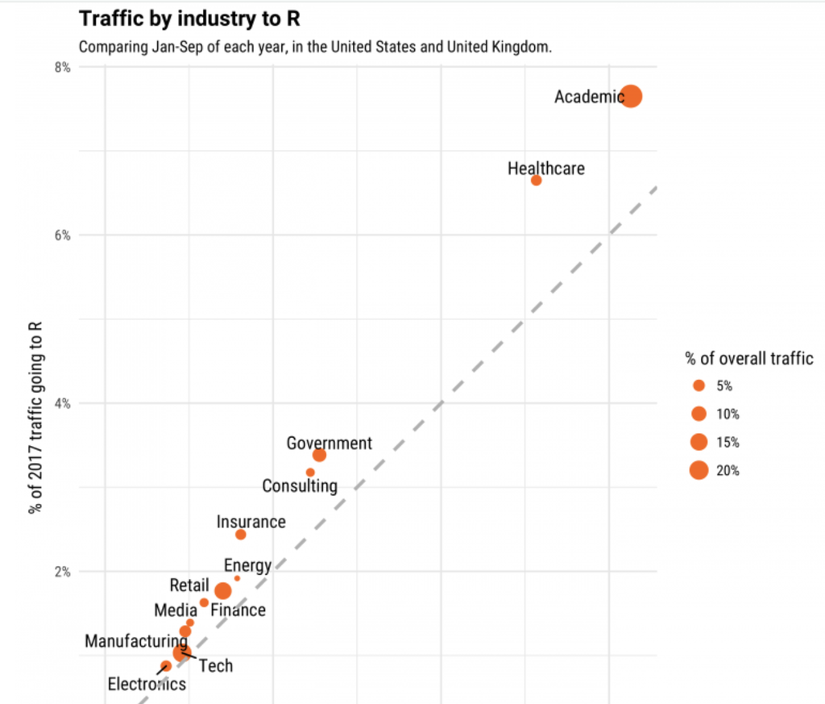

## What can we do with R

[figure not shown]

## Slide with math

We can write math equation

\[ J(\theta ) = -\frac{1}{m}\sum [y^{(i)}log(p^{(i)})+(1-y^{(i)})log(1-p^{(i)})] \]

## Connect to the world bank

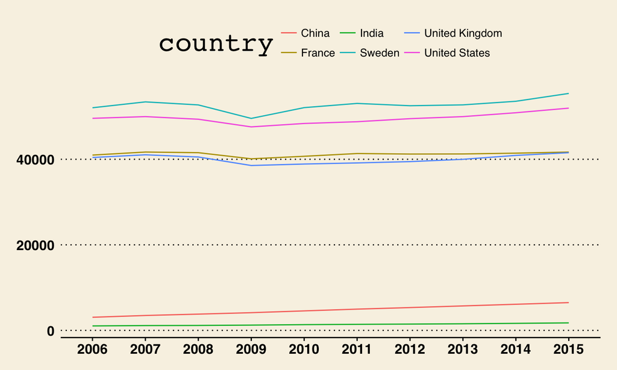

## Stata format

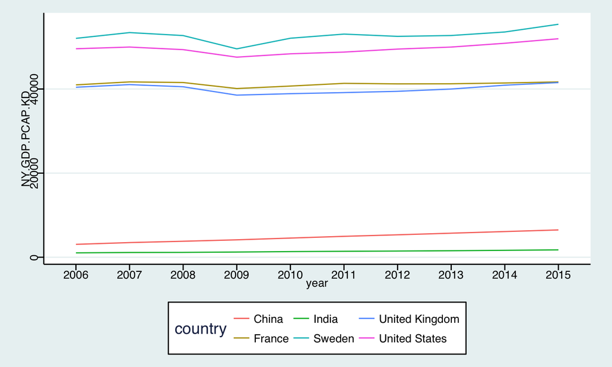

## Import data From Any Format

- CSV file

```
##               X  mpg cyl disp  hp drat    wt  qsec vs am gear carb
## 1     Mazda RX4 21.0   6  160 110 3.90 2.620 16.46  0  1    4    4
## 2 Mazda RX4 Wag 21.0   6  160 110 3.90 2.875 17.02  0  1    4    4
## 3    Datsun 710 22.8   4  108  93 3.85 2.320 18.61  1  1    4    1
```

- STATA

```
## # A tibble: 3 x 4
##   admit   gre   gpa  rank
##   <dbl> <dbl> <dbl> <dbl>
## 1     0   380  3.61     3
## 2     1   660  3.67     3
## 3     1   800  4.00     1
```

## Import data From Any Format

- Excel

```
## # A tibble: 71 x 2
##    weight      feed
##     <dbl>     <chr>
##  1    179 horsebean
##  2    160 horsebean
##  3    136 horsebean
##  4    227 horsebean
##  5    217 horsebean
##  6    168 horsebean
##  7    108 horsebean
##  8    124 horsebean
##  9    143 horsebean
## 10    140 horsebean
## # ... with 61 more rows
```

- R also accepts SAS, SPSS + connect easily with DropBox and Google Drive

## Import data From the Web

```
## The Greatest Showman is rated 8.0/10
## from Internet Movie Database and released in 20 Dec 2017
```

[figure not shown]

## R pipeline

- R pipeline feature makes the manipulation clean, fast and less prompt to error
- R pipeline is a code which performs steps without **saving** intermediate steps to the hard drive
- Let's consider a project where we need to:
  - Import two datasets
  - Merge them together
  - Create a new variable
  - Summary statitstics within groups
- R pipeline is definitelly the right candidate

## Generate the data table

- Table User

| ID | name | age | occupation |
| --- | --- | --- | --- |
| 1 | John | 21 | Student |
| 2 | Jack | 28 | Employee |

- Table items

| ID | price | quantity |
| --- | --- | --- |
| 1 | 1 | 1 |
| 3 | 4 | 5 |
| 5 | 10 | 5 |

## Example

```r
items %>%
  # Merge
  left_join(users) %>%
  # Create group
  group_by(name) %>%
  # Create average basket
  mutate(average_basket = crossprod(price, Quantity)/sum(Quantity))%>%
  # Summarize
  summarise(average_basket = mean(average_basket),mean_price=  mean(price), count = n()) %>%
  # ascending sort
  arrange(mean_price)
```

```
## # A tibble: 5 x 4
##     name average_basket mean_price count
##   <fctr>          <dbl>      <dbl> <int>
## 1   Jack       3.000000   3.000000     1
## 2   John       4.333333   3.500000     2
## 3 AMELIA       7.000000   7.000000     1
## 4  ELLIS       7.222222   7.600000     5
## 5 SOPHIE       8.625000   7.666667     3
```

## Graphics with R

- Graphics in R follows the ['The Grammar of Graphics'](https://www.amazon.com/Grammar-Graphics-Statistics-Computing/dp/0387245448)
  - **Data**: the raw data that you want to plot
  - **Geometries**: the shapes that will represent the data
  - **Aesthetics**: for a given geometry, we have certain parameters we must set
  - **Scale**: the transformation which maps data to the aesthetic dimensions, such as the data range, plot width, or colors associated with different factors
- Let's see some [examples](http://r-statistics.co/Top50-Ggplot2-Visualizations-MasterList-R-Code.html)

## R and Econometrics

- We can do a some regressions, get the results and export it for publication

**Regression Results**

|  | *Dependent variable:* |  |  |
| --- | --- | --- | --- |
|  | rating |  | high.rating |
|  | *OLS* |  | *probit* |
|  | (1) | (2) | (3) |
| complaints | 0.692*** | 0.682*** |  |
|  | (0.149) | (0.129) |  |
| privileges | -0.104 | -0.103 |  |
|  | (0.135) | (0.129) |  |
| learning | 0.249 | 0.238* | 0.164*** |
|  | (0.160) | (0.139) | (0.053) |
| raises | -0.033 |  |  |
|  | (0.202) |  |  |
| critical | 0.015 |  | -0.001 |
|  | (0.147) |  | (0.044) |
| advance |  |  | -0.062 |
|  |  |  | (0.042) |
| Constant | 11.011 | 11.258 | -7.476** |
|  | (11.704) | (7.318) | (3.570) |
| Observations | 30 | 30 | 30 |
| R<sup>2</sup> | 0.715 | 0.715 |  |
| Adjusted R<sup>2</sup> | 0.656 | 0.682 |  |
| Log Likelihood |  |  | -9.087 |
| Akaike Inf. Crit. |  |  | 26.175 |
| Residual Std. Error | 7.139 (df = 24) | 6.863 (df = 26) |  |
| F Statistic | 12.063*** (df = 5; 24) | 21.743*** (df = 3; 26) |  |
| *Note:* | p<0.1; p<0.05; p<0.01 |  |  |

## Create and Share Your App

- We can share our results with the world thanks to **Shiny app**.
- This [app](https://datascienced91c.shinyapps.io/WBIndicators/) has been developped by Daniele Landolo. It shows the world bank data nicely.
- Another simple one for the GDP/cap from the world bank: [app](https://sbell2.shinyapps.io/final_shiny/)
- My app is stored in my [website](http://www.pintudata.com/marketing/customers-centric-metric-shiny-app/)

## GitHub: Plateform to manage project

- My [GitHub](https://github.com/thomaspernet/tutorial-r-paris-1)
- GitHub is a plateform to manage, check and share projects.
- Everyone in your project can see what edit has been done.
- Project revisions can be discussed publicly, so a mass of experts can contribute knowledge and collaborate to advance a project forward.
- GitHub is primarly used for Data Science. Academic can found particular interested to get benefit from the collaboration and sharing plateform.